# D607 - Assignment 4 - Tidying Data

Marco Castro

2024-09-28

## Overview

In this assigment, we were tasked with importing a messy (un-tidy) dataset, performing tiddying operations, and performing some basic analysis on our data.

First, I read the csv stored on my github page

```r
# load messy dataframe from github page
messy_numbersense <- read_csv("https://raw.githubusercontent.com/mcastro64/d607-assignments/refs/heads/master/assignment-04/assigment4_data.csv")
messy_numbersense |>
  gt() |>
  tab_spanner(
    label = 'On Time',
    columns = matches("On Time*")
  ) |>
  tab_spanner(
    label = 'Delayed',
    columns = matches("Delayed*")
  )
```

| airline | On Time On Time - Los Angeles | On Time On Time - Phoenix | On Time On Time - San Diego | On Time On Time - San Francisco | On Time On Time - Seattle | Delayed Delayed - Los Angeles | Delayed Delayed - Phoenix | Delayed Delayed - San Diego | Delayed Delayed - San Francisco | Delayed Delayed - Seattle |
| --- | --- | --- | --- | --- | --- | --- | --- | --- | --- | --- |
| ALASKA | 497 | 221 | 212 | 503 | 1841 | 62 | 12 | 20 | 102 | 305 |
| AM WEST | 694 | 4840 | 383 | 320 | 201 | 117 | 415 | 65 | 129 | 61 |

## Pivoting Data

```r
numbersense_longer <- messy_numbersense |>
  pivot_longer(
   cols = !(airline),
    names_to = c("status", "destination"),
    names_sep = " - ",
    values_to = "flights"
  )

numbersense_longer |>
  gt()
```

| airline | status | destination | flights |
| --- | --- | --- | --- |
| ALASKA | On Time | Los Angeles | 497 |
| ALASKA | On Time | Phoenix | 221 |
| ALASKA | On Time | San Diego | 212 |
| ALASKA | On Time | San Francisco | 503 |
| ALASKA | On Time | Seattle | 1841 |
| ALASKA | Delayed | Los Angeles | 62 |
| ALASKA | Delayed | Phoenix | 12 |
| ALASKA | Delayed | San Diego | 20 |
| ALASKA | Delayed | San Francisco | 102 |
| ALASKA | Delayed | Seattle | 305 |
| AM WEST | On Time | Los Angeles | 694 |
| AM WEST | On Time | Phoenix | 4840 |
| AM WEST | On Time | San Diego | 383 |
| AM WEST | On Time | San Francisco | 320 |
| AM WEST | On Time | Seattle | 201 |
| AM WEST | Delayed | Los Angeles | 117 |
| AM WEST | Delayed | Phoenix | 415 |
| AM WEST | Delayed | San Diego | 65 |
| AM WEST | Delayed | San Francisco | 129 |
| AM WEST | Delayed | Seattle | 61 |

## Calculating Frequency Delayed and On-time

### Step 1: Calculating total flights by destination airline

Next, I wanted to be able to calculate the percentage of flights that were delayed by airline destination. To do this, I first calculated the total number of flights per airline destination using *group_by* and *summarise* to perform a *sum* calculation across all flights for every airline going to a specific destination, iregardless of status (on-time/delayed).

```r
# calculate total number of flights per airline destination
total_flights_per_airline_destination <- numbersense_longer |>
  group_by(airline, destination) |>
  summarise(
    total_flights = sum(flights)
  )
total_flights_per_airline_destination
```

```
## # A tibble: 10 × 3
## # Groups:   airline [2]
##    airline destination   total_flights
##    <chr>   <chr>                 <dbl>
##  1 ALASKA  Los Angeles             559
##  2 ALASKA  Phoenix                 233
##  3 ALASKA  San Diego               232
##  4 ALASKA  San Francisco           605
##  5 ALASKA  Seattle                2146
##  6 AM WEST Los Angeles             811
##  7 AM WEST Phoenix                5255
##  8 AM WEST San Diego               448
##  9 AM WEST San Francisco           449
## 10 AM WEST Seattle                 262
```

### Step 2: Joining datasets

Next, I used a *left_join* to combine our dataframe in long form and our dataframe with total flights per airline destination. As we are focusing on delayed flights, I used the *filter* function on the status column to limit our results to flights with a “Delayed” status.

```r
# join long flights table and total flights table
# then calculate frequence of delays
delayed_flights_observations <- numbersense_longer |>
  left_join(total_flights_per_airline_destination, join_by(airline == airline, destination == destination)) |>
  filter(status == "Delayed") |>
  rename(delayed_flights = flights)

delayed_flights_observations |>
  gt() |>
  tab_header("Delayed Flights by Airline Destination")
```

Delayed Flights by Airline Destination

| airline | status | destination | delayed_flights | total_flights |
| --- | --- | --- | --- | --- |
| ALASKA | Delayed | Los Angeles | 62 | 559 |
| ALASKA | Delayed | Phoenix | 12 | 233 |
| ALASKA | Delayed | San Diego | 20 | 232 |
| ALASKA | Delayed | San Francisco | 102 | 605 |
| ALASKA | Delayed | Seattle | 305 | 2146 |
| AM WEST | Delayed | Los Angeles | 117 | 811 |
| AM WEST | Delayed | Phoenix | 415 | 5255 |
| AM WEST | Delayed | San Diego | 65 | 448 |
| AM WEST | Delayed | San Francisco | 129 | 449 |
| AM WEST | Delayed | Seattle | 61 | 262 |

### Step 3: Calculating Overall Frequency of Delayed Flights by Airline

I wanted to get a sense of what percentage of flights were delayed overall per airline, regardless of destination. Working with the dataframe output from step 2, I again used *group_by* and *summarize* to calculate the number of delayed flights per airline, the total number of flights per airline and the percentage of flights delayed by airline.

```r
summary_delayed_flights_by_airline <- delayed_flights_observations |>
  group_by(airline) |>
  summarize(
    delayed_flights_by_airline = sum(delayed_flights),
    total_flights_by_airline = sum(total_flights),
    percent_delayed_by_airline = round(delayed_flights_by_airline / total_flights_by_airline, 3)
  )


summary_delayed_flights_by_airline |>
  gt() |>
  fmt_percent(percent_delayed_by_airline) |>
  tab_header("Overall Frequency of Delayed Flights by Airline") |>
  cols_label(
    airline = "Airlane",
    delayed_flights_by_airline = "# Flights Delayed",
    total_flights_by_airline = "Total Flights",
    percent_delayed_by_airline = "% Flights Delayed"
  )
```

Overall Frequency of Delayed Flights by Airline

| Airlane | # Flights Delayed | Total Flights | % Flights Delayed |
| --- | --- | --- | --- |
| ALASKA | 501 | 3775 | 13.30% |
| AM WEST | 787 | 7225 | 10.90% |

### Step 4: Calculating Frequency of Delayed Flights by Airline Destination

Next, I performed the same calculation on our *delayed_flights_observations* dataframe to calculate the number of delayed flights per airline destination, the total number of flights per airline destination and the percentage of flights delayed by airline destination.

```r
delayed_flights_by_airline_destination <- delayed_flights_observations |>
  mutate(percent_delayed = delayed_flights/total_flights) |>
  subset(select = c(airline, destination, delayed_flights, percent_delayed))

delayed_flights_by_airline_destination |>
  gt() |>
  fmt_percent(percent_delayed) |>
  tab_header("Frequency of Delayed Flights by Airline Destination") |>
  cols_label(
    airline = "Airlane",
    delayed_flights = "# Flights Delayed",
    percent_delayed = "% Flights Delayed"
  )
```

Frequency of Delayed Flights by Airline Destination

| Airlane | destination | # Flights Delayed | % Flights Delayed |
| --- | --- | --- | --- |
| ALASKA | Los Angeles | 62 | 11.09% |
| ALASKA | Phoenix | 12 | 5.15% |
| ALASKA | San Diego | 20 | 8.62% |
| ALASKA | San Francisco | 102 | 16.86% |
| ALASKA | Seattle | 305 | 14.21% |
| AM WEST | Los Angeles | 117 | 14.43% |
| AM WEST | Phoenix | 415 | 7.90% |
| AM WEST | San Diego | 65 | 14.51% |
| AM WEST | San Francisco | 129 | 28.73% |
| AM WEST | Seattle | 61 | 23.28% |

## Comparing our results

### Building a bar chart for the count of flights delayed

Using ggplot, I created a simple bar chart plotting airlines and the count of delayed flights. I used the parameter position=“dodge” to transform the result from a stacked bar chart to a individual bars for each destination along the x-axis.

```r
delayed_flights_count_chart <- ggplot(delayed_flights_by_airline_destination, aes(x=airline, y=delayed_flights, fill=destination)) +
  geom_bar(
    stat='identity',
    position = position_dodge(.85),
    width = .7
  ) +
  labs(
    title = "Counts of Airline Flights Delayed per Destination",
    x = "Airline",
    y = "Number of Flights Delayed"
  ) +
  geom_text(
    aes(label = delayed_flights),
    vjust = -0.5,
    size = 7,
    size.unit = "pt",
    position = position_dodge(.7)
  ) +
  theme(
    plot.title = element_text(size = 10),
    legend.position = "bottom",
    aspect.ratio = 4/5
  ) +
  ylim(0, 450)
```

### Building a bar chart for the frequency of flights delayed

I also created a simple bar chart plotting airlines and the percentage of delayed flights. I used the parameter position=“dodge” to transform the result from a stacked bar chart to a individual bars for each destination along the x-axis.

```r
delayed_flights_freq_chart <- ggplot(delayed_flights_by_airline_destination, aes(x=airline, y=percent_delayed, fill=destination)) +
  geom_bar(
    stat = 'identity',
    position=position_dodge(.85),
    width = 0.7
  ) +
  labs(
    title = "% of Airline Flights Delayed per Destination",
    x = "Airline",
    y = "Percent of Flights Delayed"
  ) +
  scale_y_continuous(labels = scales::percent) +
  geom_text(
    aes(label = paste(round(percent_delayed* 100, 1), "%")),
    vjust = -0.5,
    size = 7,
    size.unit = "pt",
    position = position_dodge(.85)
  ) +
  theme(
    plot.title = element_text(size = 10),
    legend.position = "bottom",
    aspect.ratio = 4/5
  ) +
  ylim(0, .35)
```

I used ggpubr to plot them side-by-side for comparison.

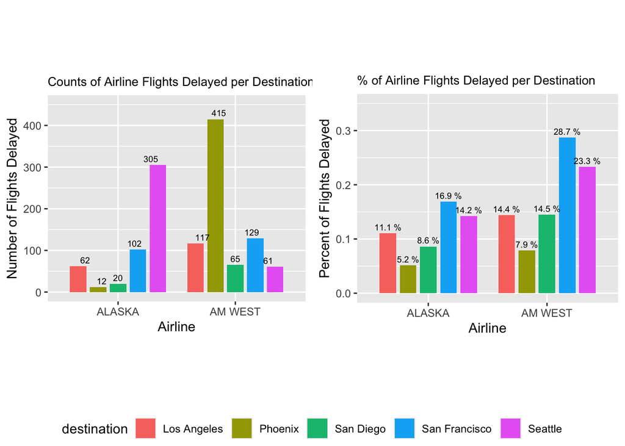

```r
ggarrange(delayed_flights_count_chart, delayed_flights_freq_chart, ncol=2, common.legend = TRUE, legend="bottom")
```

## Conclusion Examining raw counts, AM West airline’s flights to Phoenix had the most delays of any group with 415 delayed arrivals. However, when we compare percent of flights delayed, we see that AM West to Phoenix actually had the second lowest percent of delayed flights (7.9%), second only to Alaska Airline’s flight to Phoenix (5.2%). Looking at the total number of flights per airline destination table helps us confirm that AM West to Phoenix had the most flights of any airline to any destination with 5255. Additionally, flights to Phoenix from AM West and Alaska airlines were below their overall percent of delayed flights (10.9% and 13.3% respectively).